# Computer Hardware

Khanh Le

2023-04-18

## Bước 1: Load packages

Chúng ta bắt đầu với việc cài đặt package.

(Trong trường hợp đã cài trước thì chúng ta có thể bỏ qua phần này)

```r
install.packages('plyr', repos = "http://cran.us.r-project.org")
install.packages("dplyr", repos = "http://cran.us.r-project.org")
install.packages("hrbrthemes", repos = "http://cran.us.r-project.org")
install.packages("gganimate", repos = "http://cran.us.r-project.org")
install.packages("gapminder", repos = "http://cran.us.r-project.org")
install.packages("babynames", repos = "http://cran.us.r-project.org")
install.packages("ggthemes", repos = "http://cran.us.r-project.org")
```

```r
install.packages("cowplot", repos = "http://cran.us.r-project.org")
install.packages("ggplot2", repos = "http://cran.us.r-project.org")
```

Sau khi đã cài đặt xong, chúng ta có thể load các package bằng hàm `library()`

```r
library(skimr)
library(hrbrthemes)
library(gganimate)
```

```r
library(gapminder)
library(babynames)
library(ggthemes)
library(cowplot)
library(ggplot2)
library(dplyr)
library(readr)
```

## Bước 2: Import data

Tập dữ liệu được sử dụng trong bài tập lớn này là Computer Hardware Data Set (https://archive.ics.uci.edu/ml/datasets/Computer+Hardware).

Dữ liệu có thể được download từ trang UCI Machine Learning Repository: https://archive.ics.uci.edu/ml/datasets/Computer+Hardware

Sau khi đã tải về, ta có thể dùng hàm `read_csv()` để đọc dữ liệu từ file “machine.data” và lưu với tên `original_data` và đặt tên cho các cột dữ liệu .

```r
original_data <- read_csv("data/machine.data")
```

```
## ──────────────────────────────────────────────────────── Delimiter: "," chr
## (2): adviser, 32/60 dbl (8): 125, 256...4, 6000, 256...6, 16, 128, 198, 199
```

```r
names(original_data) <- c("vendor_name", "model_name", "MYCT", "MMIN", "MMAX", "CACH", "CHMIN", "CHMAX", "PRP", "ERP")
```

Dùng hàm `colnames()` để kiểm tra tên các cột dữ liệu:

```r
colnames(original_data)
```

```
##  [1] "vendor_name" "model_name"  "MYCT"        "MMIN"        "MMAX"
##  [6] "CACH"        "CHMIN"       "CHMAX"       "PRP"         "ERP"
```

## Bước 3: Tìm hiểu tập dữ liệu

Trước khi làm sạch tập dữ liệu, chúng ta cần phải tìm hiểu nó. Sử dụng hàm `head()` để lấy ra 6 dòng đầu tiên:

```r
head(original_data)
```

```
## # A tibble: 6 × 10
##   vendor_name model_name  MYCT  MMIN  MMAX  CACH CHMIN CHMAX   PRP   ERP
##   <chr>       <chr>      <dbl> <dbl> <dbl> <dbl> <dbl> <dbl> <dbl> <dbl>
## 1 amdahl      470v/7        29  8000 32000    32     8    32   269   253
## 2 amdahl      470v/7a       29  8000 32000    32     8    32   220   253
## 3 amdahl      470v/7b       29  8000 32000    32     8    32   172   253
## 4 amdahl      470v/7c       29  8000 16000    32     8    16   132   132
## 5 amdahl      470v/b        26  8000 32000    64     8    32   318   290
## 6 amdahl      580-5840      23 16000 32000    64    16    32   367   381
```

Sử dụng hàm `str()` và `glimpse()` để có cái nhìn tổng quan hơn về dữ liệu:

```r
str(original_data)
```

```
## spc_tbl_ [208 × 10] (S3: spec_tbl_df/tbl_df/tbl/data.frame)
##  $ vendor_name: chr [1:208] "amdahl" "amdahl" "amdahl" "amdahl" ...
##  $ model_name : chr [1:208] "470v/7" "470v/7a" "470v/7b" "470v/7c" ...
##  $ MYCT       : num [1:208] 29 29 29 29 26 23 23 23 23 400 ...
##  $ MMIN       : num [1:208] 8000 8000 8000 8000 8000 16000 16000 16000 32000 1000 ...
##  $ MMAX       : num [1:208] 32000 32000 32000 16000 32000 32000 32000 64000 64000 3000 ...
##  $ CACH       : num [1:208] 32 32 32 32 64 64 64 64 128 0 ...
##  $ CHMIN      : num [1:208] 8 8 8 8 8 16 16 16 32 1 ...
##  $ CHMAX      : num [1:208] 32 32 32 16 32 32 32 32 64 2 ...
##  $ PRP        : num [1:208] 269 220 172 132 318 ...
##  $ ERP        : num [1:208] 253 253 253 132 290 ...
##  - attr(*, "spec")=
##   .. cols(
##   ..   adviser = col_character(),
##   ..   `32/60` = col_character(),
##   ..   `125` = col_double(),
##   ..   `256...4` = col_double(),
##   ..   `6000` = col_double(),
##   ..   `256...6` = col_double(),
##   ..   `16` = col_double(),
##   ..   `128` = col_double(),
##   ..   `198` = col_double(),
##   ..   `199` = col_double()
##   .. )
##  - attr(*, "problems")=<externalptr>
```

```r
glimpse(original_data)
```

```
## Rows: 208
## Columns: 10
## $ vendor_name <chr> "amdahl", "amdahl", "amdahl", "amdahl", "amdahl", "amdahl"…
## $ model_name  <chr> "470v/7", "470v/7a", "470v/7b", "470v/7c", "470v/b", "580-…
## $ MYCT        <dbl> 29, 29, 29, 29, 26, 23, 23, 23, 23, 400, 400, 60, 50, 350,…
## $ MMIN        <dbl> 8000, 8000, 8000, 8000, 8000, 16000, 16000, 16000, 32000, …
## $ MMAX        <dbl> 32000, 32000, 32000, 16000, 32000, 32000, 32000, 64000, 64…
## $ CACH        <dbl> 32, 32, 32, 32, 64, 64, 64, 64, 128, 0, 4, 65, 65, 0, 0, 8…
## $ CHMIN       <dbl> 8, 8, 8, 8, 8, 16, 16, 16, 32, 1, 1, 1, 1, 1, 4, 4, 7, 5, …
## $ CHMAX       <dbl> 32, 32, 32, 16, 32, 32, 32, 32, 64, 2, 6, 8, 8, 4, 32, 15,…
## $ PRP         <dbl> 269, 220, 172, 132, 318, 367, 489, 636, 1144, 38, 40, 92, …
## $ ERP         <dbl> 253, 253, 253, 132, 290, 381, 381, 749, 1238, 23, 24, 70, …
```

Sử dụng hàm `skim_without_charts()`:

```r
skim_without_charts(original_data)
```

Data summary

| Name | original_data |
| --- | --- |
| Number of rows | 208 |
| Number of columns | 10 |
| _______________________ |  |
| Column type frequency: |  |
| character | 2 |
| numeric | 8 |
| ________________________ |  |
| Group variables | None |

**Variable type: character**

| skim_variable | n_missing | complete_rate | min | max | empty | n_unique | whitespace |
| --- | --- | --- | --- | --- | --- | --- | --- |
| vendor_name | 0 | 1 | 2 | 12 | 0 | 29 | 0 |
| model_name | 0 | 1 | 2 | 18 | 0 | 208 | 0 |

**Variable type: numeric**

| skim_variable | n_missing | complete_rate | mean | sd | p0 | p25 | p50 | p75 | p100 |
| --- | --- | --- | --- | --- | --- | --- | --- | --- | --- |
| MYCT | 0 | 1 | 204.20 | 260.83 | 17 | 50 | 110.0 | 225.0 | 1500 |
| MMIN | 0 | 1 | 2880.54 | 3883.84 | 64 | 768 | 2000.0 | 4000.0 | 32000 |
| MMAX | 0 | 1 | 11824.02 | 11747.92 | 64 | 4000 | 8000.0 | 16000.0 | 64000 |
| CACH | 0 | 1 | 24.10 | 37.42 | 0 | 0 | 8.0 | 32.0 | 256 |
| CHMIN | 0 | 1 | 4.64 | 6.79 | 0 | 1 | 2.0 | 6.0 | 52 |
| CHMAX | 0 | 1 | 17.74 | 24.91 | 0 | 5 | 8.0 | 24.0 | 176 |
| PRP | 0 | 1 | 105.18 | 161.09 | 6 | 27 | 49.5 | 111.5 | 1150 |
| ERP | 0 | 1 | 98.85 | 154.97 | 15 | 28 | 45.0 | 99.5 | 1238 |

## Step 4: Cleaning your data

Trích các thuộc tính cần sử dụng

```r
hardware_df <- original_data %>%
  select(MYCT, MMIN, MMAX, CACH, CHMIN, CHMAX, PRP, ERP)
```

Kiểm tra missing value

```r
hardware_df %>% sapply(function(col) sum(is.na(col)))
```

```
##  MYCT  MMIN  MMAX  CACH CHMIN CHMAX   PRP   ERP
##     0     0     0     0     0     0     0     0
```

## Bước 5: Vẽ đồ thị

Biểu đồ Histogram của Relative Performance

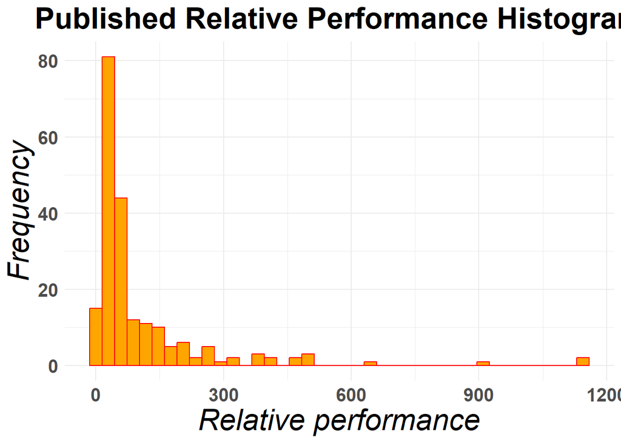

```r
options(repr.plot.width = 14, repr.plot.height = 6)

x <- ggplot(data = hardware_df, mapping = aes(x = PRP)) +
  geom_histogram(bins = 40, fill = "orange", color = "#FF0000") +
  xlab("Relative performance") +
  ylab("Frequency") +
  ggtitle("Published Relative Performance Histogram") +
  theme_minimal() +
  theme(plot.title = element_text(size = 24, hjust = .5, face = "bold"),
        axis.title.x = element_text(size = 24, hjust = .5, face = "italic"),
        axis.title.y = element_text(size = 24, hjust = .5, face = "italic"),
        axis.text.x = element_text(size = 15, face = "bold"),
        axis.text.y = element_text(size = 15, face = "bold"),
        legend.position = "none")

x
```

```r
hist1 <- ggplot(data = hardware_df, mapping = aes(x = MYCT)) +
  geom_histogram(bins = 40, fill = "blue", color = "cyan") +
  xlab("Machine Cycle Time (ns)") +
  ylab("Frequency") +
  ggtitle("Machine Cycle Time Histogram") +
  theme_minimal() +
  theme(plot.title = element_text(size = 8, hjust = .5, face = "bold"),
        axis.title.x = element_text(size = 8, hjust = .5, face = "italic"),
        axis.title.y = element_text(size = 8, hjust = .5, face = "italic"),
        axis.text.x = element_text(size = 5, face = "bold"),
        axis.text.y = element_text(size = 5, face = "bold"),
        legend.position = "none")
```

```r
hist2 <- ggplot(data = hardware_df, mapping = aes(x = MMIN)) +
  geom_histogram(bins = 40, fill = "blue", color = "cyan") +
  xlab("Minimum Main Memory Size (KB)") +
  ylab("Frequency") +
  ggtitle("Minimum Main Memory Histogram") +
  theme_minimal() +
  theme(plot.title = element_text(size = 8, hjust = .5, face = "bold"),
        axis.title.x = element_text(size = 8, hjust = .5, face = "italic"),
        axis.title.y = element_text(size = 8, hjust = .5, face = "italic"),
        axis.text.x = element_text(size = 5, face = "bold"),
        axis.text.y = element_text(size = 5, face = "bold"),
        legend.position = "none")
```

```r
hist3 <- ggplot(data = hardware_df, mapping = aes(x = MMAX)) +
  geom_histogram(bins = 40, fill = "#00CED1", color = "#7FFF00") +
  xlab("Maximum Main Memory Size (KB)") +
  ylab("Frequency") +
  ggtitle("Maximum Main Memory Histogram") +
  theme_minimal() +
  theme(plot.title = element_text(size = 8, hjust = .5, face = "bold"),
        axis.title.x = element_text(size = 8, hjust = .5, face = "italic"),
        axis.title.y = element_text(size = 8, hjust = .5, face = "italic"),
        axis.text.x = element_text(size = 5, face = "bold"),
        axis.text.y = element_text(size = 5, face = "bold"),
        legend.position = "none")
```

```r
hist4 <- ggplot(data = hardware_df, mapping = aes(x = CACH)) +
  geom_histogram(bins = 40, fill = "#00CED1", color = "#7FFF00") +
  xlab("Cache Size (KB)") +
  ylab("Frequency") +
  ggtitle("Cache Memory Histogram") +
  theme_minimal() +
  theme(plot.title = element_text(size = 8, hjust = .5, face = "bold"),
        axis.title.x = element_text(size = 8, hjust = .5, face = "italic"),
        axis.title.y = element_text(size = 8, hjust = .5, face = "italic"),
        axis.text.x = element_text(size = 5, face = "bold"),
        axis.text.y = element_text(size = 5, face = "bold"),
        legend.position = "none")
```

```r
hist5 <- ggplot(data = hardware_df, mapping = aes(x = CHMIN)) +
  geom_histogram(bins = 40, fill = "#4B0082", color = "#FF00FF") +
  xlab("Channels (units)") +
  ylab("Frequency") +
  ggtitle("Minimum Channels Histogram") +
  theme_minimal() +
  theme(plot.title = element_text(size = 8, hjust = .5, face = "bold"),
        axis.title.x = element_text(size = 8, hjust = .5, face = "italic"),
        axis.title.y = element_text(size = 8, hjust = .5, face = "italic"),
        axis.text.x = element_text(size = 5, face = "bold"),
        axis.text.y = element_text(size = 5, face = "bold"),
        legend.position = "none")
```

```r
hist6 <- ggplot(data = hardware_df, mapping = aes(x = CHMAX)) +
  geom_histogram(bins = 40, fill = "#4B0082", color = "#FF00FF") +
  xlab("Channels (units)") +
  ylab("Frequency") +
  ggtitle("Maximum Channels Histogram") +
  theme_minimal() +
  theme(plot.title = element_text(size = 8, hjust = .5, face = "bold"),
        axis.title.x = element_text(size = 8, hjust = .5, face = "italic"),
        axis.title.y = element_text(size = 8, hjust = .5, face = "italic"),
        axis.text.x = element_text(size = 5, face = "bold"),
        axis.text.y = element_text(size = 5, face = "bold"),
        legend.position = "none")
```

Tổng hợp các biểu đồ Histogram:

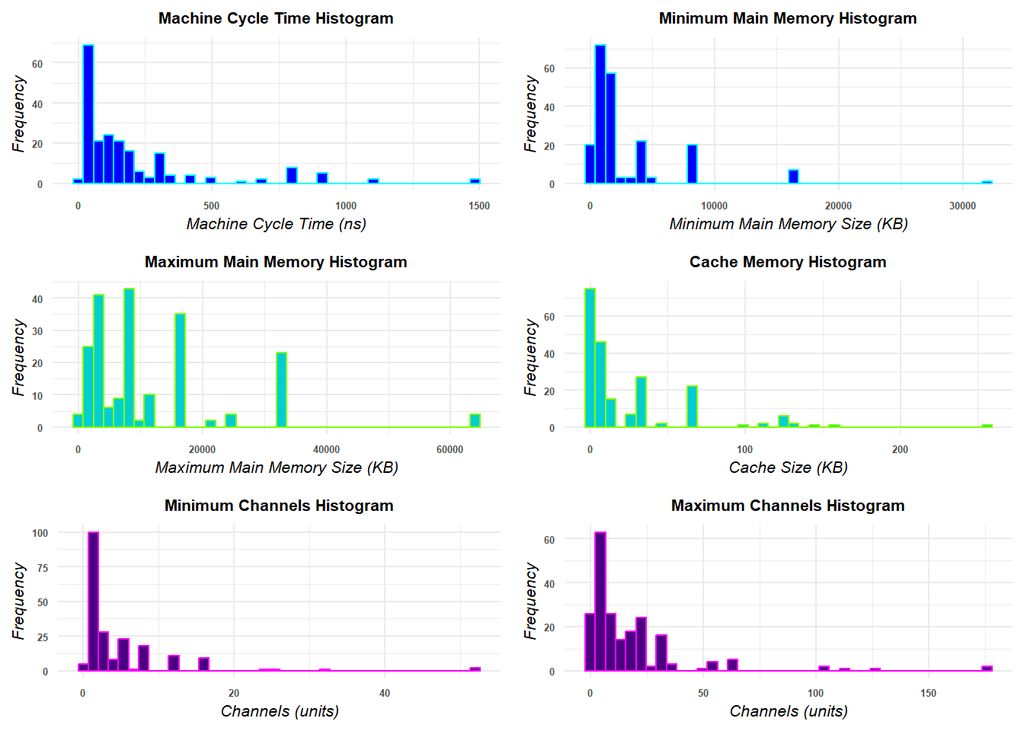

```r
plot_grid(hist1, hist2, hist3, hist4, hist5, hist6, nrow = 3, ncol = 2)
```

## Bước 6: Thống kê dữ liệu Tính toán các giá trị thống kê: Mean, Median, Standard deivation, Min, Max

```r
means <- hardware_df %>% sapply(mean)
medians <- hardware_df %>% sapply(median)
sds <- hardware_df %>% sapply(sd)
mins <- hardware_df %>% sapply(min)
maxs <- hardware_df %>% sapply(max)
summary <- as.data.frame(cbind(means, medians, sds, mins, maxs))
names(summary) <- c("mean", "median", "sd", "min", "max")

summary
```

```
##               mean median           sd min   max
## MYCT    204.201923  110.0   260.833016  17  1500
## MMIN   2880.538462 2000.0  3883.839300  64 32000
## MMAX  11824.019231 8000.0 11747.916663  64 64000
## CACH     24.096154    8.0    37.417999   0   256
## CHMIN     4.644231    2.0     6.787198   0    52
## CHMAX    17.740385    8.0    24.913375   0   176
## PRP     105.177885   49.5   161.090223   6  1150
## ERP      98.850962   45.0   154.974961  15  1238
```

## Bước 7: Chuẩn hóa dữ liệu

Để chuẩn hóa dữ liệu và dự đoán chính xác, ta lấy logarit giá trị các cột dữ liệu

```r
hardware_df$MYCT <- log(hardware_df$MYCT)
hardware_df$MMIN <- log(hardware_df$MMIN)
hardware_df$MMAX <- log(hardware_df$MMAX)
hardware_df$CACH <- log(hardware_df$CACH + 1)
hardware_df$CHMIN <- log(hardware_df$CHMIN + 1)
hardware_df$CHMAX <- log(hardware_df$CHMAX + 1)
hardware_df$PRP <- log(hardware_df$PRP)
```

```r
## hardware_df %>% cov() %>% as.data.frame()
## hardware_df %>% cor() %>% as.data.frame()
## hardware_df %>% pairs()
## pairs(hardware_df)
```

## Bước 8: Mô hình hồi quy

Xây dựng mô hình hồi quy

```r
linearModule <-lm(PRP~MYCT+MMIN+MMAX+CACH+CHMIN+CHMAX,data=hardware_df)
summary(linearModule)
```

```
##
## Call:
## lm(formula = PRP ~ MYCT + MMIN + MMAX + CACH + CHMIN + CHMAX,
##     data = hardware_df)
##
## Residuals:
##      Min       1Q   Median       3Q      Max
## -1.36311 -0.29567 -0.00241  0.24638  1.40859
##
## Coefficients:
##              Estimate Std. Error t value Pr(>|t|)
## (Intercept) -1.344255   0.548867  -2.449  0.01518 *
## MYCT         0.003298   0.048407   0.068  0.94575
## MMIN         0.205471   0.050096   4.102 5.96e-05 ***
## MMAX         0.325431   0.047724   6.819 1.05e-10 ***
## CACH         0.183943   0.025526   7.206 1.14e-11 ***
## CHMIN        0.188642   0.060759   3.105  0.00218 **
## CHMAX        0.128880   0.044820   2.876  0.00447 **
## ---
## Signif. codes:  0 '***' 0.001 '**' 0.01 '*' 0.05 '.' 0.1 ' ' 1
##
## Residual standard error: 0.4398 on 201 degrees of freedom
## Multiple R-squared:  0.8287, Adjusted R-squared:  0.8236
## F-statistic: 162.1 on 6 and 201 DF,  p-value: < 2.2e-16
```

Kiểm tra các thông số mô hình

```r
#3.7.2
linearModule$coefficients
```

```
##  (Intercept)         MYCT         MMIN         MMAX         CACH        CHMIN
## -1.344255324  0.003297915  0.205471486  0.325431024  0.183942606  0.188642007
##        CHMAX
##  0.128880134
```

```r
SSE <- (linearModule$residuals ^ 2) %>% sum()
SSR <- ((linearModule$fitted.values - mean(hardware_df$PRP)) ^ 2) %>% sum()
SST <- ((hardware_df$PRP - mean(hardware_df$PRP)) ^ 2) %>% sum()
ss <- as.data.frame(c(SSE, SSR, SST), row.names = c("SSE", "SSR", "SST"))
names(ss) <- c("Value")
ss
```

```
##         Value
## SSE  38.88369
## SSR 188.15003
## SST 227.03372
```

```r
#3.7.3
summary(linearModule)$sigma
```

```
## [1] 0.4398309
```

```r
#3.7.4
summary(linearModule)$adj.r.squared
```

```
## [1] 0.8236192
```

Trực quan mô hình

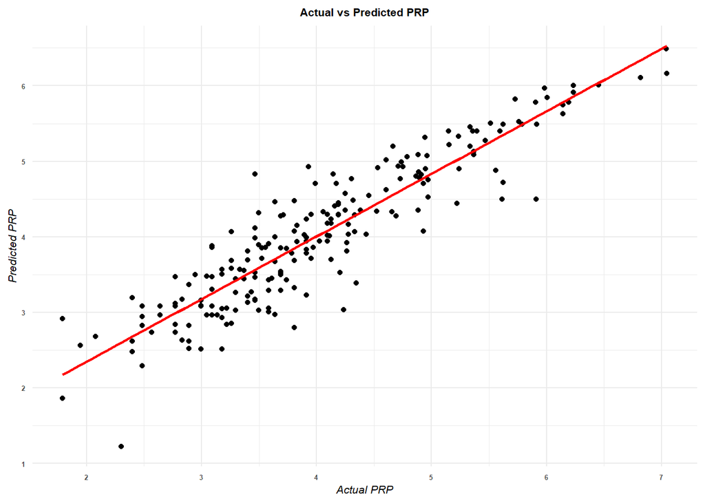

```r
ggplot(data = hardware_df, aes(x = PRP, y = linearModule$fitted.values)) +
  geom_point() +
  geom_smooth(method = "lm", se = FALSE, color = "red") +
  xlab("Actual PRP") +
  ylab("Predicted PRP") +
  ggtitle("Actual vs Predicted PRP") +
  theme_minimal() +
  theme(plot.title = element_text(size = 8, hjust = .5, face = "bold"),
        axis.title.x = element_text(size = 8, hjust = .5, face = "italic"),
        axis.title.y = element_text(size = 8, hjust = .5, face = "italic"),
        axis.text.x = element_text(size = 5, face = "bold"),
        axis.text.y = element_text(size = 5, face = "bold"),
        legend.position = "none")
```